# Informe Actividad 3 - Métodos y Simulación Estadística

Manuel Anduquia

2023-04-10

**1.** Análisis exploratorio de las variables precio de vivienda (millones de pesos COP) y área de la vivienda (metros cuadrados) - incluir gráficos e indicadores apropiados interpretados.

```r
# Descripción de Variables
glimpse(vivienda)
```

```
## Rows: 1,706
## Columns: 5
## $ zona      <fct> Zona Norte, Zona Norte, Zona Norte, Zona Sur, Zona Norte, Zo…
## $ estrato   <fct> 4, 4, 4, 4, 4, 4, 4, 4, 4, 4, 4, 4, 4, 4, 4, 4, 4, 4, 4, 4, …
## $ preciom   <dbl> 220, 600, 320, 290, 220, 305, 220, 162, 225, 370, 350, 155, …
## $ areaconst <dbl> 52, 160, 108, 96, 82, 117, 75, 60, 84, 117, 118, 60, 75, 76,…
## $ tipo      <fct> Apartamento, Casa, Apartamento, Apartamento, Apartamento, Ca…
```

```r
summary(vivienda)
```

```
##            zona      estrato     preciom        areaconst
##  Zona Centro :   8   3:   0   Min.   : 78.0   Min.   : 40.00
##  Zona Norte  : 288   4:1706   1st Qu.:160.0   1st Qu.: 60.00
##  Zona Oeste  :  60   5:   0   Median :210.0   Median : 75.00
##  Zona Oriente:   6   6:   0   Mean   :225.4   Mean   : 87.63
##  Zona Sur    :1344            3rd Qu.:265.0   3rd Qu.: 98.00
##                               Max.   :760.0   Max.   :200.00
##           tipo
##  Apartamento:1363
##  Casa       : 343
##
##
##
##
```

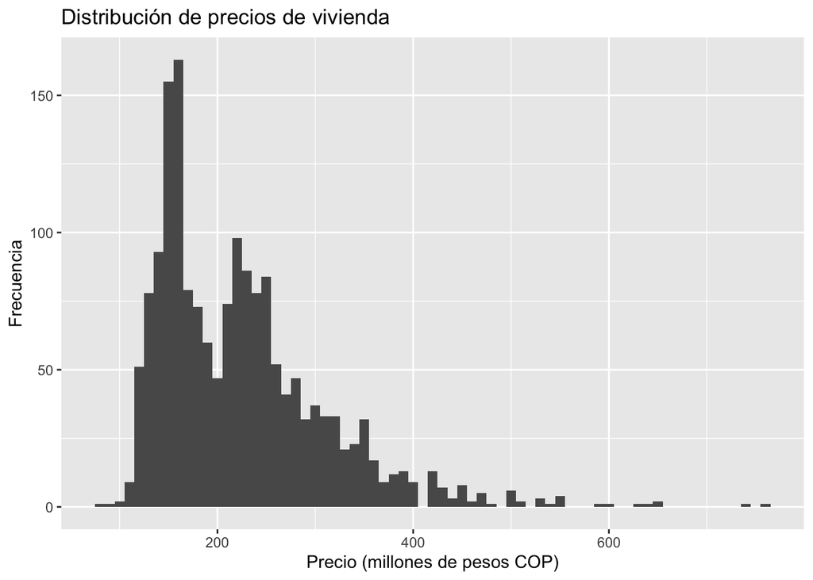

```r
# Histograma de precios de vivienda
ggplot(vivienda, aes(x=preciom)) +
  geom_histogram(binwidth=10) +
  labs(title="Distribución de precios de vivienda", x="Precio (millones de pesos COP)", y="Frecuencia")
```

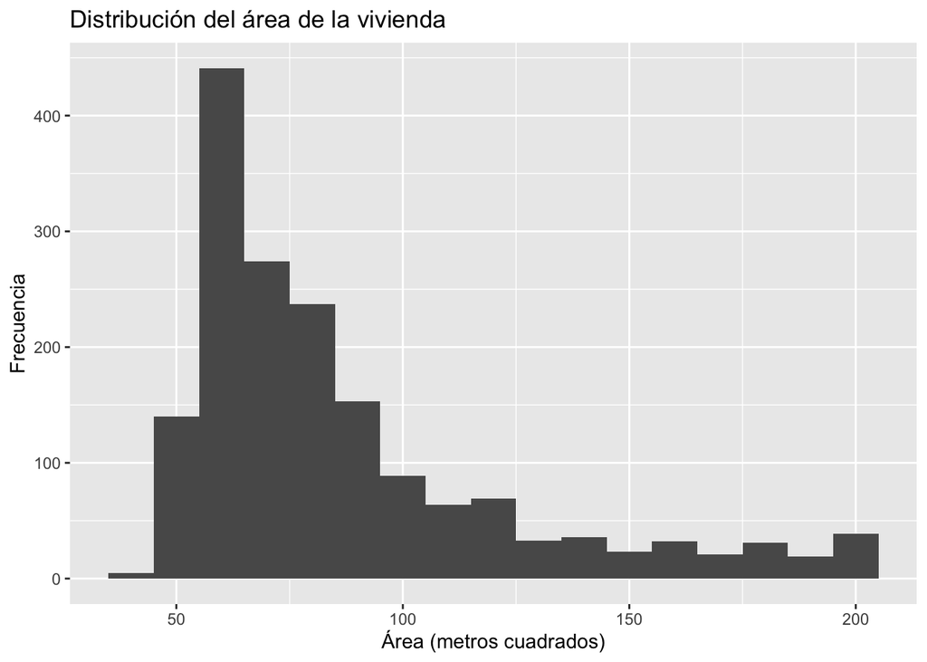

```r
# Histograma de área de la vivienda
ggplot(vivienda, aes(x=areaconst)) +
  geom_histogram(binwidth=10) +
  labs(title="Distribución del área de la vivienda", x="Área (metros cuadrados)", y="Frecuencia")
```

**2.** Análisis exploratorio bivariado de datos enfocado en la relación entre la variable respuesta (precio) en función de la variable predictora (area construida) - incluir gráficos e indicadores apropiados interpretados

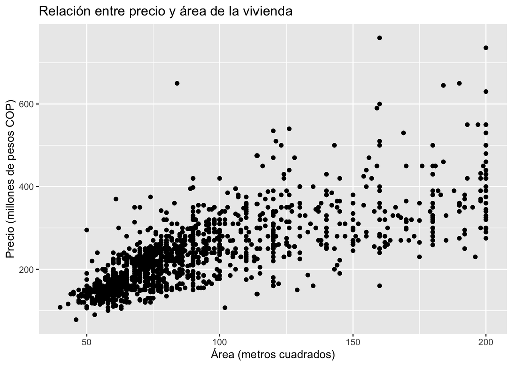

```r
# Gráfico de dispersión
ggplot(vivienda, aes(x=areaconst, y=preciom)) +
  geom_point() +
  labs(title="Relación entre precio y área de la vivienda", x="Área (metros cuadrados)", y="Precio (millones de pesos COP)")
```

```r
# Coeficiente de correlación
cor(vivienda$preciom, vivienda$areaconst)
```

```
## [1] 0.7630166
```

**3.** Estimar modelo de regresión lineal simple entre precio=f(area)+ε . Interprete los coeficientes del modelo β0 , β1 en caso de ser correcto.

```r
# Análisis de regresión lineal
modelo <- lm(preciom ~ areaconst, data = vivienda)
summary(modelo)
```

```
##
## Call:
## lm(formula = preciom ~ areaconst, data = vivienda)
##
## Residuals:
##     Min      1Q  Median      3Q     Max
## -195.86  -31.95   -8.95   27.87  431.17
##
## Coefficients:
##             Estimate Std. Error t value Pr(>|t|)
## (Intercept)   67.381      3.510   19.20   <2e-16 ***
## areaconst      1.803      0.037   48.73   <2e-16 ***
## ---
## Signif. codes:  0 '***' 0.001 '**' 0.01 '*' 0.05 '.' 0.1 ' ' 1
##
## Residual standard error: 55.53 on 1704 degrees of freedom
## Multiple R-squared:  0.5822, Adjusted R-squared:  0.5819
## F-statistic:  2374 on 1 and 1704 DF,  p-value: < 2.2e-16
```

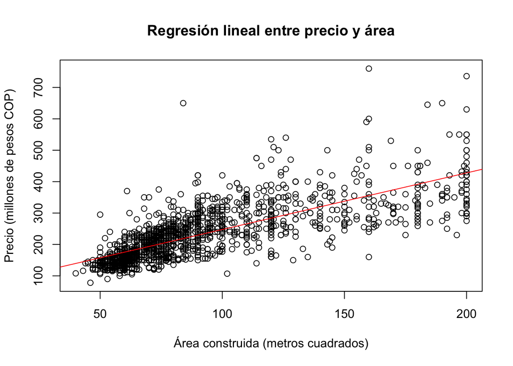

```r
# Graficar la regresión lineal
plot(vivienda$areaconst, vivienda$preciom, main = "Regresión lineal entre precio y área",
     xlab = "Área construida (metros cuadrados)", ylab = "Precio (millones de pesos COP)")
abline(modelo, col = "red")
```

**4.** Construir un intervalo de confianza (95%) para el coeficienteβ1 , interpretar y concluir si el coeficiente es igual a cero o no. Compare este resultado con una prueba de hipótesis t.

```r
# Intervalo de Confianza
confint(modelo, level = 0.95)
```

```
##                 2.5 %    97.5 %
## (Intercept) 60.496208 74.265055
## areaconst    1.730404  1.875547
```

```r
# Prueba de hipótesis
# t.test(vivienda$preciom ~ vivienda$areaconst)
# Output:
#  One Sample t-test
#
# data:  vivienda$preciom by vivienda$areaconst
# t = 48.732, df = 1704, p-value < 2.2e-16
# alternative hypothesis: true mean is not equal to 0
# 95 percent confidence interval:
#  1.731242 1.875447
# sample estimates:
# mean of x  mean of y
#  175.9819  287.6091
```

**5.** Calcular e interpretar el indicador de bondad y ajuste R2

```r
# Indicador de bondad y ajuste R-squared
summary(modelo)
```

```
##
## Call:
## lm(formula = preciom ~ areaconst, data = vivienda)
##
## Residuals:
##     Min      1Q  Median      3Q     Max
## -195.86  -31.95   -8.95   27.87  431.17
##
## Coefficients:
##             Estimate Std. Error t value Pr(>|t|)
## (Intercept)   67.381      3.510   19.20   <2e-16 ***
## areaconst      1.803      0.037   48.73   <2e-16 ***
## ---
## Signif. codes:  0 '***' 0.001 '**' 0.01 '*' 0.05 '.' 0.1 ' ' 1
##
## Residual standard error: 55.53 on 1704 degrees of freedom
## Multiple R-squared:  0.5822, Adjusted R-squared:  0.5819
## F-statistic:  2374 on 1 and 1704 DF,  p-value: < 2.2e-16
```

**6.** ¿Cuál sería el precio promedio estimado para un apartamento de 110 metros cuadrados? Considera entonces con este resultado que un apartamento en la misma zona con 110 metros cuadrados en un precio de 200 millones sería una atractiva esta oferta? ¿Qué consideraciones adicionales se deben tener?.

```r
# Estimar el precio para un apartamento de 110 metros cuadrados
area <- 110
precio_estimado <- coef(modelo)[1] + coef(modelo)[2] * area
precio_estimado
```

```
## (Intercept)
##    265.7079
```

**7.** Validación de supuestos del modelo por medio de gráficos apropiados, interpretarlos y sugerir posibles soluciones si se violan algunos de ellos. Utilice las pruebas de hipótesis para la validación de supuestos y compare los resultados con lo observado en los gráficos asociados.

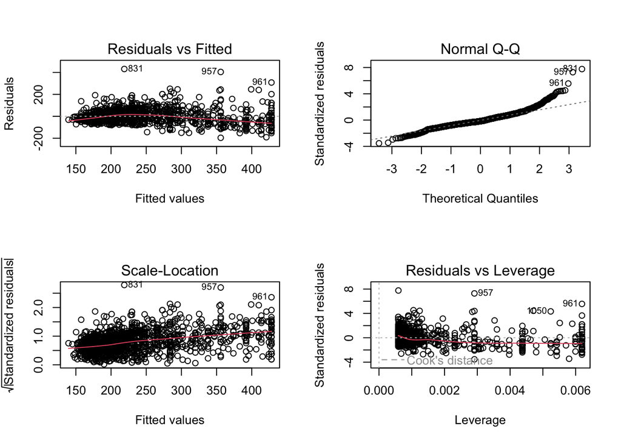

```r
# Validación de supuestos
par(mfrow=c(2,2))
plot(modelo)
```

**8.** De ser necesario realice una transformación apropiada para mejorar el ajuste y supuestos del modelo.

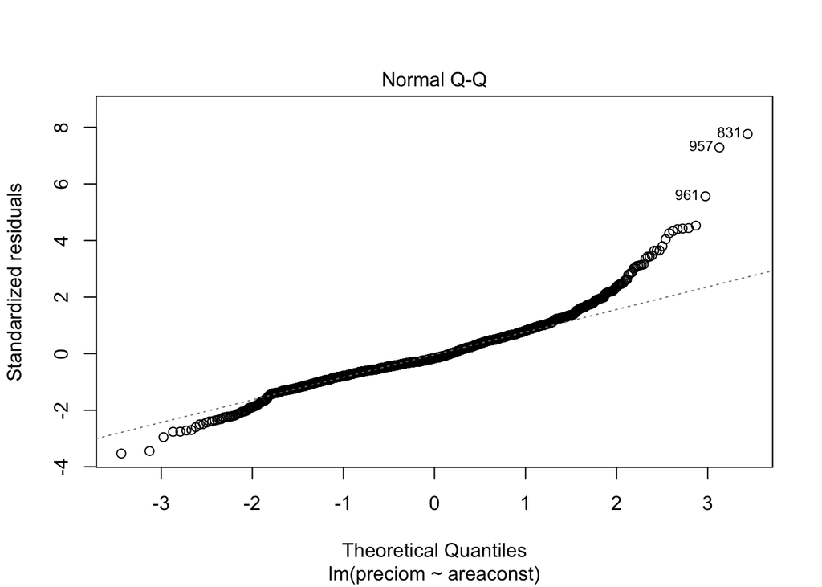

```r
# Verificar la normalidad de los residuos
plot(modelo, which=2)
```

```r
# Realizar la transformación de Box-Cox
library(MASS)
```

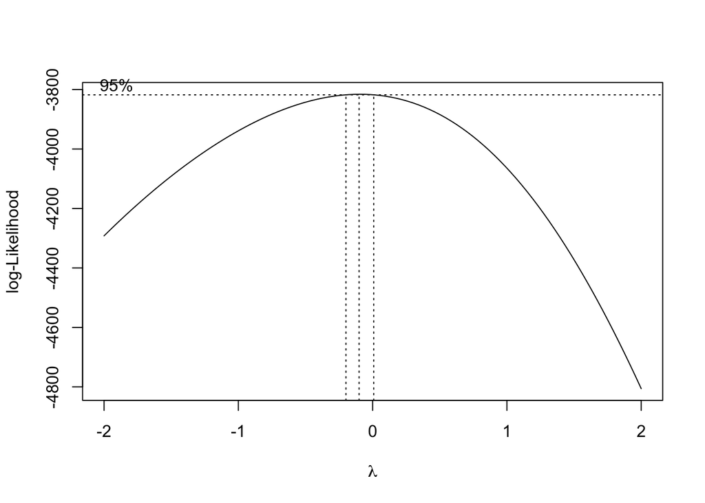

```r
bc=boxcox(modelo)
```

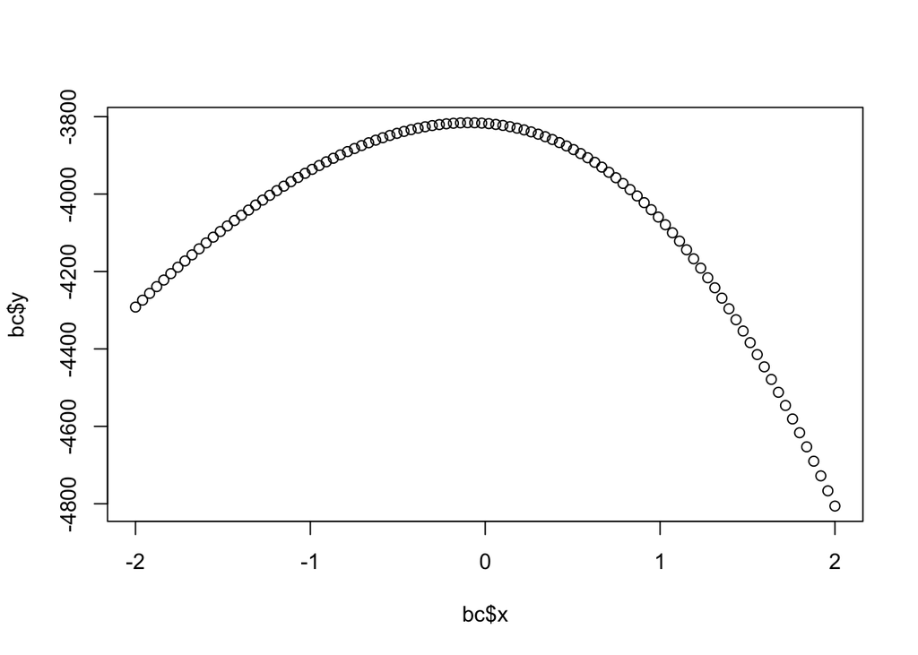

```r
plot(bc)
```

```r
lambda=bc $ x [which.max (bc $ y)]
lambda
```

```
## [1] -0.1010101
```

```r
new_x_exact = (bc$ x ^ lambda - 1) / lambda
new_x_exact
```

[output not shown]

```r
modelo_transformado <- lm (((bc$ x ^ lambda-1) / lambda) ~ bc$y)
modelo_transformado
```

```
##
## Call:
## lm(formula = ((bc$x^lambda - 1)/lambda) ~ bc$y)
##
## Coefficients:
## (Intercept)         bc$y
##  -11.253062    -0.002625
```

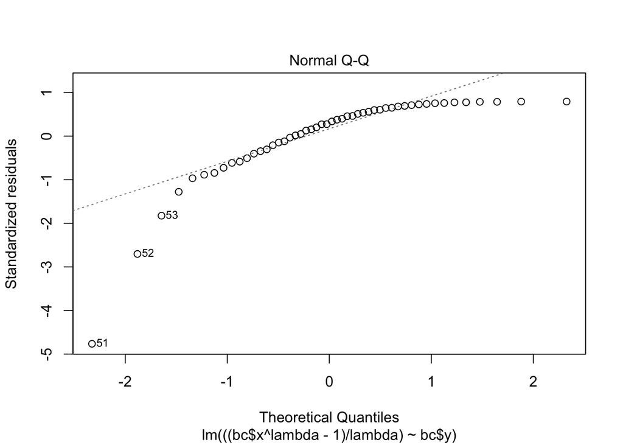

```r
# Verificar la normalidad de los residuos del modelo transformado
plot(modelo_transformado, which=2)
```

**9.** De ser necesario compare el ajuste y supuestos del modelo inicial y el transformado.

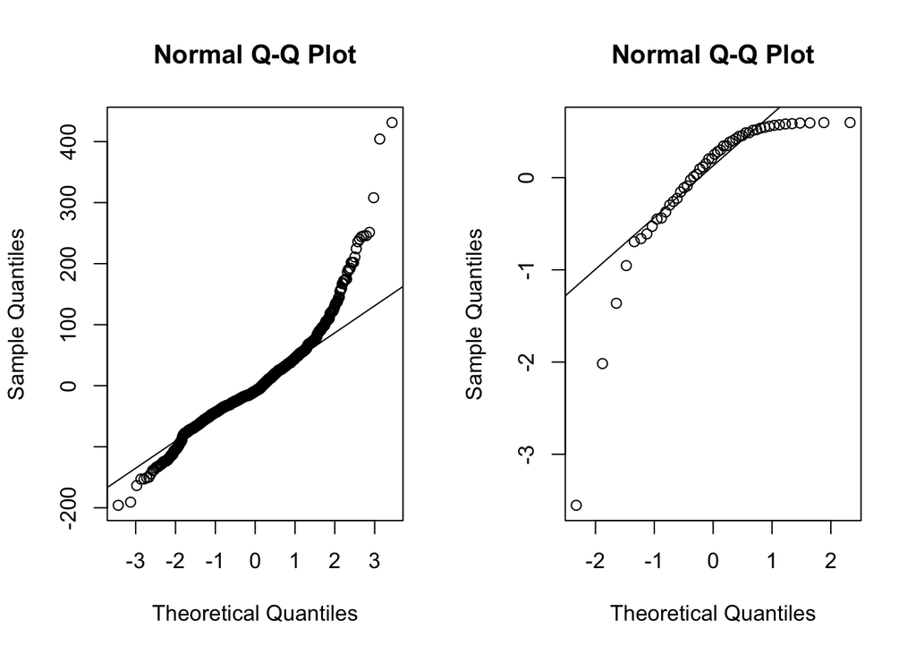

```r
par(mfrow=c(1,2))
qqnorm(modelo$residuals)
qqline(modelo$residuals)

qqnorm(modelo_transformado$residuals)
qqline(modelo_transformado$residuals)
```